# RSDB: an easy to deploy open‐source web platform for remote sensing raster and point cloud data management, exploration and processing - Stephan - - Ecography - Wiley Online Library

[figure not shown]

Software note

Open Access

# RSDB: an easy to deploy open‐source web platform for remote sensing raster and point cloud data management, exploration and processing

[Wöllauer Stephan](https://onlinelibrary.wiley.com/action/doSearch?ContribAuthorStored=Stephan%2C+W%C3%B6llauer)

[Zeuss Dirk](https://onlinelibrary.wiley.com/action/doSearch?ContribAuthorStored=Dirk%2C+Zeuss)

[Magdon Paul](https://onlinelibrary.wiley.com/action/doSearch?ContribAuthorStored=Paul%2C+Magdon)

[Nauss Thomas](https://onlinelibrary.wiley.com/action/doSearch?ContribAuthorStored=Thomas%2C+Nauss)

First published: 30 November 2020

https://doi.org/10.1111/ecog.05266

## Abstract

Monitoring biodiversity and its change over space and time is a key challenge for ecological research. Utilizing remote sensing data in ecological research has been shown to be a powerful complement to labor‐intensive field work to derive area‐wide biodiversity indices, which can also capture larger spatiotemporal areas. However, preprocessing different types of remote sensing data for specific studies often requires extensive computational skills as the algorithms for creating final data products are scattered across the literature.

The primary RSDB user interface is web browser based on management, exploration, visualization and product processing capabilities. The RSDB stores data in layers that are discoverable by textual metadata and mapping on overview maps. Individual data layers can be explored using interactive maps and 3‐D visualizations. We additionally provide a seamless connection of the RSDB's functionality with the R environment through our accompanying R package for scripting and advanced processing tasks.

We designed the RSDB to be an easily accessible solution for on‐demand processing of comprehensive biodiversity indices. To date, the RSDB has been used and tested in several studies, and we are convinced that it will continue to facilitate biodiversity monitoring via its application to ecological research.

## Introduction

Remote sensing allows us to efficiently monitor the physical properties of the environment using multi‐temporal data acquisitions of large areas (Imran et al. 2020). The use of relevant information derived from these observations has become a common approach across a wide range of disciplines, including agriculture (Luis Soca‐Munoz et al. 2020) or feature extraction (Kearney et al. 2020). At the interface between geography and ecology, remotely sensing ecosystem properties have great potential to contribute to land cover and biodiversity monitoring and research (O'Connor et al. 2015, Pettorelli et al. 2016, Vihervaara et al. 2017, Jetz et al. 2019). To successfully integrate remote sensing data into ecological research, however, requires expertise in different disciplines. Managing, processing and deriving environmental information from remote sensing data requires high‐level technical skills in the fields of remote sensing image analysis and point cloud processing. The diversity of data types from different observation platforms (e.g. satellites, airplanes and unmanned aerial systems (UAS)), and sensors (e.g. optical sensors providing raster images and light detection and ranging (LiDAR) providing point clouds) can prove challenging. Expertise in ecology is necessary to ensure targeted processing, analysis and application. Furthermore, managing large quantities of data and the efficient implementation of subject‐specific analysis routines require a high level of expertise in the computer sciences, such as service management and parallelization (Hampton et al. 2017). Therefore, simple file storage strategies and correct, albeit computation‐time expensive, software scripts quickly become impracticable, even for small remote sensing data applications and working groups.

A variety of open‐source remote sensing processing modules and toolboxes already exist. The widespread software R (R Core Team) offers a collection of functions for data processing and analysis with a focus on scripting and command‐line operations, for example, with the popular R package RSToolbox (Benjamin Leutner et al. 2019). For further information, refer to (Wegmann et al. 2016). Meanwhile, the ORFEO toolbox (<[orfeo‐toolbox.org](http://orfeo-toolbox.org/)>) provides a large variety of individual functions for basic and advanced image processing. However, there are a limited number of open‐source programs for analyzing airborne laser scanning (ALS) data. In contrast to raster data, point cloud data from ALS enables high‐resolution 3‐D representations of vegetation, including tracking changes in forest structure (Karna et al. 2020). Although ORFEO also supports LiDAR observations through the libLAS library, most of the functions focus on raster operations. The point data abstraction library (PDAL) (PDAL Contributors 2018) began as a twin of the widespread GDAL library and focuses on the efficient processing of point clouds using processing pipelines that are configured by JSON‐files (Bray 2017). Thus, users must become familiar with project‐specific processing pipeline expressions. Similar restrictions apply to the point cloud library (PCL) (Rusu and Cousins 2011), which provides a set of libraries to analyze point clouds. However, support for specific geospatial features of ALS data is limited, and users must be able to develop applications in C++ (Stroustrup 2013). The R package lidR (Roussel and Auty 2019) is specifically designed to analyze ALS data and offers many tailor‐made functions for processing. To visualize 3‐D point clouds, Potree (Schütz 2016) and Plasio (<plas.io>) are efficient web‐based renderers, but they do not provide processing or data management features. For spatial analyses and the visualization of remote sensing data, a variety of large open‐source geographic information systems (GIS) exist, which also offer functions that can process remote sensing data. These solutions can range from complete GIS suites of GRASS GIS (<[grass.osgeo.org](http://grass.osgeo.org/)>) and SAGA GIS (<[saga‐gis.org](http://saga-gis.org/)>) to the best‐known project QGIS (<[qgis.org](http://qgis.org/)>). Furthermore, system specific products, such as the Sentinel toolbox (<sentinel.esa.int/web/sentinel/toolboxes>), are also available. However, many of the aforementioned solutions are not optimized to process workflows with (large) remote sensing datasets, rely on plug‐ins, such as the ORFEO Toolbox, or are restricted to a certain type of sensor (e.g. the Sentinel toolbox). Note that there are also some open‐source data storage and mapping projects, such as GeoNode (<[geonode.org](http://geonode.org/)>), which uses GeoServer (<[geoserver.org](http://geoserver.org/)>) as a backend, but is limited to raster data. One comprehensive data management and data science solution with an improved organized data management focus is the Rasdaman project (<[rasdaman.org](http://rasdaman.org/)>), which is based on a flexible and powerful database engine. However, it is only optimized for raster data and its installation and maintenance requires database and system administrator skills (see documentation at <[doc.rasdaman.org](http://doc.rasdaman.org/)>). A non‐open‐source, but for scientific community freely available system, is the Google Earth Engine (Gorelick et al. 2017). As a cloud‐based solution, no installation is required and large collections of raster data, mostly from satellites, are provided. For usage, scripting skills in Python or JavaScript and knowledge of the Google Earth Engine environment are necessary. Thus, there are many open‐source projects working on specific aspects of remote sensing project workflows. However, they either require high‐level computer science skills to be used (e.g. PCL, Rasdaman), focus on very specific datasets (e.g. the Sentinel toolbox) or provide no data lifecycle management capacities (QGIS, R, GRASS GIS and SAGA GIS). Besides some very small projects, only PDAL, LidR and PCL offer specific functions to process ALS data with open‐source licenses.

To further promote the use of remote sensing data in ecological research projects, we developed a novel remote sensing database (RSDB) that is an easy‐to‐set up, easy‐to‐use, and provides a server‐based solution that considers the full lifecycle of different remote sensing data types, while offering customizable functions and visualizations for individual experts and teams. Our objective is to enable scientists and professionals working in ecology, who are not computer, data science or remote sensing experts to work with remote sensing data. With our client‐server approach, it is possible to distinguish between data providers and data consumers, which is preferable for long‐term research projects facing rapidly increasing amounts of data.

The RSDB is a comprehensive server solution for remote sensing dataset management, processing and visualization. Our solution supports the efficient storage and processing of raster, point cloud and vector data layers. A self‐explanatory browser interface allows access to data management, exploration, visualization, product generation and export functions. Raster layer visualization is also possible through any GIS system supporting the widespread web map service (WMS) protocol. The RSDB processes data via an associated R package. With the intuitive web browser interface, a predefined set of standard products can be generated easily and on demand, while the R package can be used for more complex data retrieval and processing tasks. The R package connects the RSDB to the R ecosystem, which is widely used in ecological research. Thus, scientists familiar with the R environment can engage in interactive or scripted processing and visualization of remote sensing data directly in their favorite environment. To facilitate easy access and support already existing individual workflows, retrieved datasets in the RSDB come in structures typical for the R environment, complete with annotated metadata. Additionally, the RSDB R package includes data transformation functions to directly apply methods including the lidR package for ALS data or the hsdar package (Lehnert et al. 2019) for hyperspectral raster data. Only very basic computer‐administrative skills are necessary to install the RSDB on personal computers or on‐premise servers. Moreover, the RSDB requires only a simple Java (Arnold et al. 2000) runtime environment, thereby allowing scientists to work with the RSDB without being distracted by sophisticated computer science and administrative aspects. The RSDB can be run as an online platform where users access data via an R‐ or web interface, which can also be accessed on mobile devices. Alternatively, the RSDB may be used on a personal computer for single user usage.

## Architecture and data storage models

### Architecture (layer types)

Layers are the basic organization elements of the RSDB datasets (Fig. 1). There are several layer types that all share common metadata, including unique ID, display name, description, access control and data describing entries, such as geographic reference and projection information. One layer element contains one uniform dataset, and one ALS point cloud results from multiple flights of the same mission (with identical recording characteristics).

[figure not shown]

**Figure 1**

Open in figure viewer[PowerPoint](https://onlinelibrary.wiley.com/action/downloadFigures?id=ecog12676-fig-0001&doi=10.1111%2Fecog.05266)

RSDB organizes data in layers, including raster, point cloud, vector (points, lines, polygons), point of interest (POI) and region of interest (ROI). Layer data are stored in storage modules. Layers are accessible via several user interfaces. Data originates from remote sensing platforms with sensors (Clip arts sources: [pixabay.com](http://pixabay.com/), R Logo CC‐BY‐SA 4.0 © 2016 The R Foundation, QGIS logo CC BY‐SA 3.0 © 2004–2017 QGIS Development Team).

#### Raster layer

Spectral, radar and other raster data are stored as ‘raster layer' types in the RSDB (Fig. 2). Raster data are arranged in a uniform 2‐D grid of pixels covered by several bands that share a uniform grid, though they may originate from different sensor types. While a red–green–blue (RGB) camera image has three spectral bands, hyperspectral images can have more than one hundred bands. To document the band structure, specific metadata for spectral bands is provided, such as wavelength and bandwidth. Furthermore, multi‐temporal datasets are supported by storing timestamps to represent time series (recordings at multiple points in time) within a raster layer. To increase the computation and visualization speed (e.g. fast zooms), each band layer is linked to a pyramid of lower resolution versions (Fig. 2). On the database backend, raster bands are stored efficiently in ‘cell storage,' as described below.

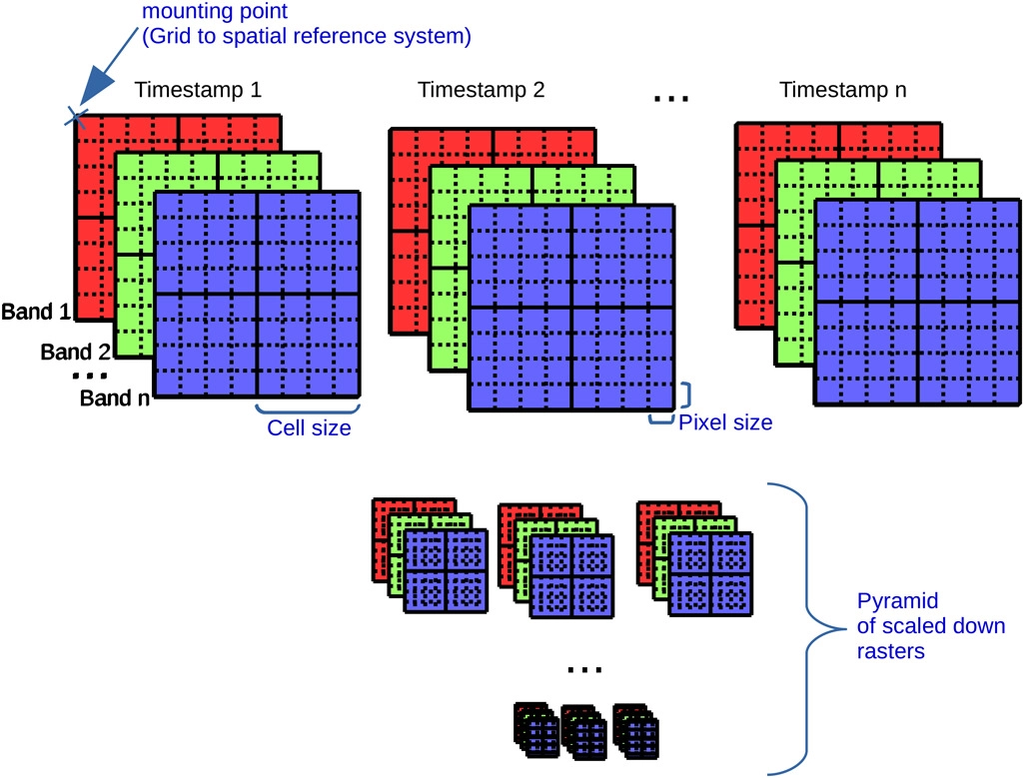

**Figure 2**

Open in figure viewer[PowerPoint](https://onlinelibrary.wiley.com/action/downloadFigures?id=ecog12676-fig-0002&doi=10.1111%2Fecog.05266)

Raster layers in RSDB are organized in bands of individual data types, which can occur at multiple timestamps. For visualizing coarser pixel resolutions, a pyramid of scaled down versions exists.

#### Point cloud layer

Point clouds from ALS or photogrammetry are stored as ‘point cloud layer' types (Fig. 3). Individual points of a cloud are arranged in a 2‐D grid of cells of equal size. Point positions are stored in a defined resolution, for example, 1 cm or 1 mm, and referenced relative to the cell origin in the bottom left corner. A set of additional properties, including scan angle, intensity and return number, is stored for all points located in a cell. All properties, including their x–y–z coordinates, are stored separately to achieve high read performance and compression efficiency (cf. column‐oriented database management systems (Stonebraker et al. 2005)). For these properties, specific storage compression methods are applied (see below).

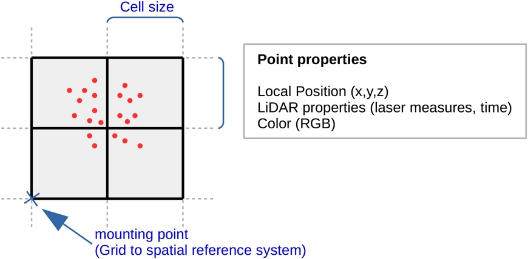

**Figure 3**

Open in figure viewer[PowerPoint](https://onlinelibrary.wiley.com/action/downloadFigures?id=ecog12676-fig-0003&doi=10.1111%2Fecog.05266)

Point cloud layers in RSDB arrange points in cells with a uniform set of properties per point.

#### ROI layer

Region of interest (ROI) layers are 2‐D areas defined by a polygon with an associated identifying name. ROIs do not contain further data. They are used to spatially select subsets from other layers, such as from point clouds or spectral raster data. Usage of these subsets, perhaps to compile training samples, is up to the data analyst's interpretation. In particular, web‐based ALS index processing (see below) is simplified by ROIs as users can select the desired ROIs and indices and receive tables of index values specifically calculated for these areas. This is very common in ecological studies, wherein field observations from sample plots should be linked to remote sensing indices.

#### POI layer

Point of interest (POI) layers are point locations in 2‐D space. A name identifies each point. POIs may be used as a location source for the processing of other layers. For example, a square‐shaped area around a POI specified by a spacing value can serve for an area‐based selection of other layers, which can easily be done using our web interface. POIs can thus be used for processing if observation locations are not clearly associated with a bounding area or if ROI information is missing.

#### Vector layer

Data from the raster or point cloud layers serve as sources for processing a final product that is related to geographic locations or areas. For this purpose and for map visualization overlays, we provide the ‘vector layer' type. It comprises points, lines or polygons with associated properties. This corresponds to the GDAL/OGR simple feature data model (OpenGIS simple feature specification [ogc.org](http://ogc.org/)), which is used as a storage backend that allows the import of common vector formats, such as Shapefile, GeoJSON or GeoPackage.

A more specific vector data model is often more appropriate for product processing. For this purpose, the automatic extraction of POIs (points only) and ROIs (polygons only) can be activated for each vector layer via a checkbox in our web browser interface.

### Storage model

The arrangement of data into cells is used as the storage type for raster and point cloud layers (Fig. 4). A multidimensional key with integer values for each dimension orders the referenced cells, wherein each cell contains arbitrary byte content that is compressed for the individual layers. Compression methods include a combination of delta‐encoding, byte reordering, sign‐magnitude representation (SMR) (Zhang and Garg 2018), fastPFOR (Lemire and Boytsov 2015) or none. In addition to the individual compression methods, all data are compressed by the Z‐standard high‐performance compression algorithm to save space (Collet and Turner 2016).

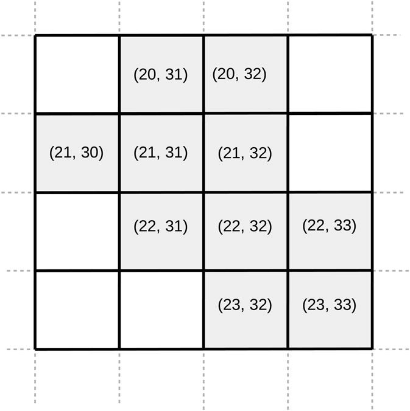

**Figure 4**

Open in figure viewer[PowerPoint](https://onlinelibrary.wiley.com/action/downloadFigures?id=ecog12676-fig-0004&doi=10.1111%2Fecog.05266)

Cells in RSDB are arranged in a regular grid. Each cell is associated with a key of several dimensions (point‐cloud dimensions: x, y; raster layer dimensions: time, band, x, y). Empty cells do not require storage space.

Retrieving several adjacent cells can be efficiently performed as a result of the implemented ordering by keys. Empty cells do not take storage space, and the beginning and end of the dimensions do not need to be specified. Hence, arbitrary cells can simply be stored without an initial configuration. We implemented a hybrid approach between disk‐based key‐value storage and in‐memory key‐value storage. Keys and on‐disk positions of values are cached in memory, and values (i.e. cells with arbitrary byte content) are stored on disk. This is a tradeoff between fast main memory and large disk storage (utilization of different storage types (Shankar et al. 2016)). Cell data are written directly to the disk and their storage is subsequently marked as ‘dirty'. When a possibly large writing operation over multiple cells finishes, a ‘flush' command writes the in‐memory data parts to the disk and revokes the ‘dirty' state. This guarantees data integrity while maintaining high performance.

## Processing methods

Layers, as described above, form the basis for the processing functions and output products of the RSDB. Thus, products are either raster or point cloud‐based. However, this distinction cannot be strictly defined as intermediate raster products from point clouds may be used for the calculation of a final point cloud index product. For example, a digital terrain model (DTM) raster is generated on demand from a point cloud, and the standard deviation of the DTM pixel values is the resulting index value.

### Raster products

In its most basic form, an RSDB raster ‘product' is a subset from a raster layer defined by sets of timestamps, bands or areas. User‐defined formulas can be used to transform raster data (Table 1) with operators to calculate spectral indices (SIs) (Turner et al. 1999). For example, users can calculate the widely used normalized difference vegetation index (NDVI) with the following: ‘(r800 – r680)/(r800 + r680)' (Tucker 1979). Here, a wavelength‐specific notation is supported, meaning the RSDB selects the best nearest band at the specified wavelengths as bands of a (multispectral or hyperspectral) raster may not be exactly centered at a requested wavelength, e.g. 798.2 nm band center instead of 800 nm band center. The advantage of wavelength‐specific notation is that the same formulas can be used for sensors with different band definitions. These formulas can be specified interactively in the RSDB to implement different indices. The RSDB includes a selection of the most common SIs, which are available by name reference, including NDVI, enhanced vegetation index (EVI) (Huete et al. 2002), soil‐adjusted vegetation index (SAVI) (Huete 1988), modified photochemical reflectance index (MPRI) (Barbosa et al. 2019) and triangular greenness index (TGI) (Hunt et al. 2013). Examples of applications of different user‐specified indices include the change detection of vegetation at the landscape level (Lyon et al. 1998) and the observation of specific crop characteristics in agriculture (Thenkabail et al. 2000). The resulting raster products may be loaded into R, visualized with the mapview R package (Appelhans et al. 2020), or further processed, perhaps to calculate the statistics across pixels of an ROI.

Table 1. Raster data in the RSDB can be transformed by formulas that are composed of operators comprising basic math and raster band selection, as well as more complex operators and compositions, such as spectral vegetation indices (SVIs). Up‐do‐date details of indices are listed in our RSDB wiki (<[github.com/environmentalinformatics‐marburg/rsdb/wiki](http://github.com/environmentalinformatics-marburg/rsdb/wiki)>)

| Operator/function | Description |
| --- | --- |
| Basic |  |
| +, −, *, /, (…) | Arithmetic |
| b<sub>i</sub> | Band selection, e.g. ‘b2' for second band |
| [b<sub>i1</sub>, b<sub>i2</sub>, …, b<sub>in</sub>] | Multi band selection, e.g. ‘[b1, b2, b3]' |
| r<sub>w</sub> | Band by wavelength, e.g. ‘r600' for 600 nm |
| Algorithm |  |
| pca | Principal component analysis |
| gap_filling | Fill pixel gaps by mean of adjacent pixels |
| euclidian_distance | Euclidean distance |
| black_point_compensation | Align band values to zero based on minimum value |
| normalised_ratio | Normalised ratio of two bands |
| normalised_difference | Normalised difference of two bands |
| Composition (SVI) |  |
| EVI | Enhanced vegetation index |
| ExG | Excess of green |
| GLI | Green leaf index |
| MGVRI | Modified green red vegetation index |
| MPRI | Modified photochemical reflectance index |
| NDVI | Normalized difference vegetation index |
| RGVBI | Red green blue vegetation index |
| SAVI | Soil‐adjusted vegetation index |
| TGI | Triangular greenness index |
| VEG | Vegetativen |

The RSDB web interface contains functionality for the GeoTIFF export of raster layers and for graphical export as PNG files (e.g. colored band mappings). For seamless figure production in R, raster data (and other layer types) can be loaded by our R package. The loaded rasters include metadata, such as the coordinate reference system, and can be processed directly by other R packages specialized in figure production, such as raster (Hijmans 2020) or tmap (Tennekes 2018). Additionally, the exported data can be loaded by software specializing in cartographic visualizations, such as QGIS.

### Point cloud products

A widespread method used to analyze point clouds in ecological research is the calculation of ALS metrics or ‘indices,' which provide aggregated information on point cloud characteristics for spatial units, such as ROIs or grid cells. Often, these metrics, for example, point density, are then related to environmental characteristics, such as vegetation density. When constructing the RSDB, we focused on metrics that are often used in the context of forest biodiversity research, but the calculation of other indices is also possible.

#### Point cloud processing

Point cloud indices in the RSDB build upon common basic products that are organized hierarchically (Fig. 5). A user‐defined ROI specifies the desired area for index calculations. As several indices depend on rasterized point cloud data (Bakx et al. 2019), such as DTMs, wider areas of points must be requested to avoid edge effects when generating such rasters. For this, a buffer of 16 m is added around the ROI, and all of the points within the extended ROI are queried from the point cloud layer. Therefore, if necessary, three rasters are generated by an index. The first is a gridded digital surface model (DSM) with a spatial resolution of 1 m, which is created using the maximum Z‐value of each grid cell. Then, a DTM is created by interpolating the points labeled as ground returns. Finally, a canopy height model (CHM) is calculated from CHM = DSM – DTM, resulting in a gridded raster with vegetation heights in each pixel. In addition to rasters, if it is necessary, several point‐based products are generated for an index. This includes using the original ROI to filter the exact points covered by its area, and the absolute height values derived from the point Z‐values using the DTM grid.

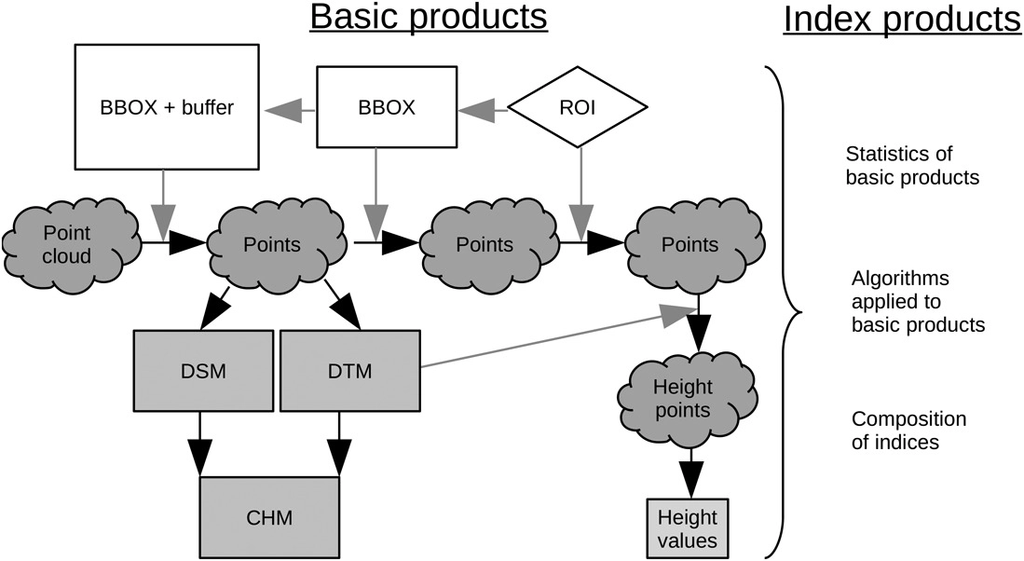

**Figure 5**

Open in figure viewer[PowerPoint](https://onlinelibrary.wiley.com/action/downloadFigures?id=ecog12676-fig-0005&doi=10.1111%2Fecog.05266)

Point cloud index processing in RSDB builds upon basic products. The basic products (and their depending products) that are needed for the requested index products are generated and cached for reuse (gray entities). A user request comprises a polygon (region of interest (ROI)) as input for the desired area. A bounding box (BBOX), which has a buffer area around the BBOX that specifies the subset of points loaded from the point cloud. Derived products are created on demand (black arrows). Raster products: digital surface model (DSM), digital terrain model (DTM) and canopy height model (CHM).

#### Point cloud indices

A large and comprehensive set of LiDAR indices commonly used in ecological literature are implemented in the RSDB. The indices are calculated from multiple basic products as well as other lower‐level indices (Fig. 5). In the RSDB, they are categorized into mission indices, indices of terrain, canopy, horizontal and vertical structures, and specific vegetation indices (Table 2).

| Index(‐group) | Description |
| --- | --- |
| Mission indices |  |
| Point count | Count of points in the ROI |
| Point coverage | Point gap measure |
| Point density | Count of points per m<sup>2</sup> calculated from the ROI |
| Point elevation (statistics) | statistics over point elevations (min, max, mean, SD, etc.) |
| Laser pulse (statistics) | Statistics over LiDAR pulses |
| Scan angle (statistics) | Statistics over LiDAR scan angle |
| Polygon area | Point cloud independent area of polygon |
| Bounding box area | Point cloud independent area of bounding box |
| Intensity (statistics) | Statistics on first return LiDAR intensity |
| Terrain |  |
| Elevation (statistics) | Statistics over DTM pixels |
| Surface area and ratio | Deviation from planar DTM |
| Slope (statistics) | Statistics over slope of DTM pixels |
| Aspect (statistics) | Statistics over aspect of DTM pixels |
| Canopy |  |
| Height (statistics) | Statistics over CHM pixels |
| Surface area and ratio | Deviation from planar CHM |
| Horizontal structure |  |
| Vegetation coverage | (Proportion of points ≥ specified height)/all points |
| Vertical structure |  |
| Return density (for horizontal strata) | Point density per stratum |
| Penetration rate (for horizontal strata) | Penetration density per stratum |
| Vertical distribution ratio (for horizontal strata) | Vertical density |
| Height | Statistics over vegetation point heights above ground |
| Vegetation |  |
| Aboveground biomass | Biomass estimate |
| Foliage height diversity | FHD estimate |
| Leaf area index | LAI estimate |

*Mission indices* characterize the general properties of the point cloud, and are defined by the flight mission setup, for example, sensors, repetition rates, flight heights or speed. These indices provide the basic information of the point cloud, such as point densities or scan angles, and are useful to run quality checks of the data. For example, if an area is fully covered by points, these indices will check if the point density is homogeneous or if the scan angles are unusual.

*Terrain indices* operate on a generated DTM raster and provide measures regarding terrain structure.

*Surface area* calculates the real surface area of the landscape, including elevation information, using the triangulation algorithm, as presented in (Jenness 2004). The *surface ratio* is calculated by dividing the surface area by the flat area. This ratio is used as an indicator of terrain's topographic roughness.

*Canopy indices* operate on a generated CHM, providing measures concerning the vegetation surface from a bird's eye view. Here, common descriptive statistics can be derived, including maximum, minimum and mean, wherein the latter is referred to as the mean top‐of‐canopy height (TCH), as labeled in (Müller et al. 2018).

*Horizontal structure indices* measure the horizontal point distribution, providing insights into the vegetation gap structure. *Vegetation coverage* calculates the ratio of the covered area, wherein an area is covered if the vegetation is higher than a specific height. The predefined heights are 1, 2, 5 or 10 m. Different heights are used for different scenarios. For example, low understory coverage is excluded by selecting a vegetation coverage value greater than the understory threshold of 2 m. There are three variants of coverage determination: CHM pixels, point cloud height points and ray coverage (first returns of LiDAR laser pulses).

*Vertical structure indices* measure the vertical point distribution in the horizontal strata at 1 m intervals (e.g. Strata_05 including all points at 5 m < Z ≤ 6 m where Z is the absolute height). Additionally, strata can be defined according to the typical forestry categories as canopy understory and regeneration strata. For each stratum, the *return density* measures the ratio between points within the stratum and all points. The *penetration rate* measures the ratio of points within a stratum to points within and below that stratum (Takahashi et al. 2006). Further, the *vertical distribution ratio* (VDR) is a normalized measure of the vertical distribution found by dividing the TCH by the maximum vegetation height (Müller et al. 2018). Finally, *Foliage height diversity* (FHD) is derived from the penetration rates of the canopy, understory and regeneration strata following the concept of (MacArthur and MacArthur 1961).

*Ecosystem indices* calculate specific measures of the observed ecosystem. For example, the *aboveground biomass* (AGB) is calculated using allometric models developed by (Asner and Mascaro 2014) for tropical forests. With the flexible setup of the database, the implementation of further locally adapted models can be easily implemented. The *leaf‐area index* (LAI) is estimated from the normalized point clouds in accordance with the methods of (Getzin et al. 2017). A vertical profile is generated using the number of points in each 1 m stratum, wherein points with Z < 5 m are removed to mitigate the influence of non‐leaf LiDAR points below the canopy. Along the vertical axis, the foliage profile can be calculated. Finally, the LAI value is defined by the sum of the vertical foliage profile zones (default parameters: light extinction coefficient k = 0.3, height interval h.bin = 1 and height threshold GR.threshold = 5).

Though a large variety of indices (with focus on vegetation) were implanted in the RSDB, not all user cases will be covered. Therefore, the RSDB offers the option to implement customized indices directly in R using the aforementioned products and indices. Further, there are additional products available in the RSDB to facilitate this task, for example, voxels (3‐D pixels) can be used for analyzing vertical structures. For details, please see our continuously updated documentation online (<[github.com/environmentalinformatics‐marburg/rsdb/wiki/Point‐cloud‐indices](http://github.com/environmentalinformatics-marburg/rsdb/wiki/Point-cloud-indices)>).

#### Index raster products from point clouds

Thus far, we have discussed the calculation of point cloud indices for predefined ROIs. However, if models linking indices with ecological information must be built, researchers often desire to make predictions for larger areas to create seamless maps. With the RSDB function ‘index rasters', index values can be calculated for large areas by tessellating the region of interest into a raster determined by user‐specified pixel size and extent. The function then fills the raster with index values. If more than one index is calculated, a multiband raster is created with one index per band. In contrast to a limited ROI, which is processed within seconds, extensive index rasters may take hours or days to complete depending on their region and pixel sizes. Therefore, a simple request–response scheme is not appropriate. Thus, the index raster task is sent to the RSDB, which proceeds to run the calculation in the background. The resulting raster layers can be processed, visualized and exported in the same manner as all the other RSDB raster layers. For long‐running tasks, a product preview is available.

## Workflow: an example with LiDAR data

### Introduction

Our guiding example involves LiDAR data processing of European forests, wherein the RSDB is used to predict the biodiversity variables published in Bae et al. (2019).

### Installation

The RSDB application can be downloaded from our project homepage, where we also provide an installation manual (details in section ‘Software availability').

### Preprocessing

As source data, we use point clouds recorded by LiDAR for one flying campaign for three regions from the Biodiversity Exploratories in Germany (Fischer 2010). Data are stored in LAS files (specification at <github.com/ASPRSorg/LAS>) with one directory per region, totaling 2.7 TB. Points are classified as ground or non‐ground.

### Data import

On the web interface, begin a task to import the LAS files (‘import') (Fig. 6). When the task finishes, generate a raster map from the point cloud to create a visualization(called ‘rasterize'). Both tasks can alternatively be specified with the command line.

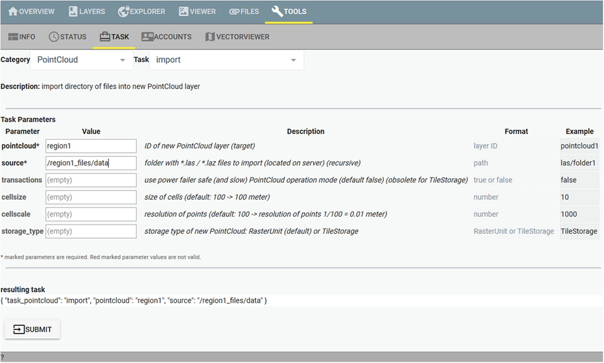

**Figure 6**

Open in figure viewer[PowerPoint](https://onlinelibrary.wiley.com/action/downloadFigures?id=ecog12676-fig-0006&doi=10.1111%2Fecog.05266)

Processing tasks in RSDB can be started by using the input forms of the web interface. Here is a prepared task for LAS file import.

Within the Biodiversity Exploratories, the study plots are spread across the three regions. Each forest plot is 100 × 100 m. All plots are stored as polygons in a shapefile that can be uploaded to RSDB, where they will be stored as a vector layer.

For raster data import, several potentially overlapping raster files of the same resolution will result in one RSDB raster layer. Uploaded raster files should be pre‐processed, which can include orthorectification or atmospheric corrections, to form uniform aerophotogrammetric mosaics, such as with OpenDroneMap (<[opendronemap.org](http://opendronemap.org/)>).

### Exploration

The web interface contains a map viewer to explore the rasterized point cloud (Fig. 7). A vector layer overlay containing plot polygons can be selected. Zooming into individual plots allows users to check the accuracy of the data alignment. At the plot level, point clouds can be inspected in interactive 3‐D views of raw points or by on‐demand created surface rasters (e.g. DTM, DSM, CHM).

[figure not shown]

**Figure 7**

Open in figure viewer[PowerPoint](https://onlinelibrary.wiley.com/action/downloadFigures?id=ecog12676-fig-0007&doi=10.1111%2Fecog.05266)

The map viewer of the RSDB web interface allows users to view point clouds with vector overlays as well as select areas for 3‐D view and data export.

### Processing

At this stage, point cloud indices at the plot level can be calculated. For this purpose, the ROI representation of the plot vector layer is activated at the web interface. In the point cloud indices processing view of the web interface, all relevant ROIs are selected (forest plots in this case) (Fig. 8). The desired indices are selected, and the processing can begin. The results can be viewed as a table and downloaded as a csv file. For more automated workflows, the processing can also be executed with R scripts by utilizing our accompanying R package. For example, a forest gap mask based on rasterized point cloud indices can be created for further evaluations (details in <[github.com/environmentalinformatics‐marburg/rsdb‐data](http://github.com/environmentalinformatics-marburg/rsdb-data)>).

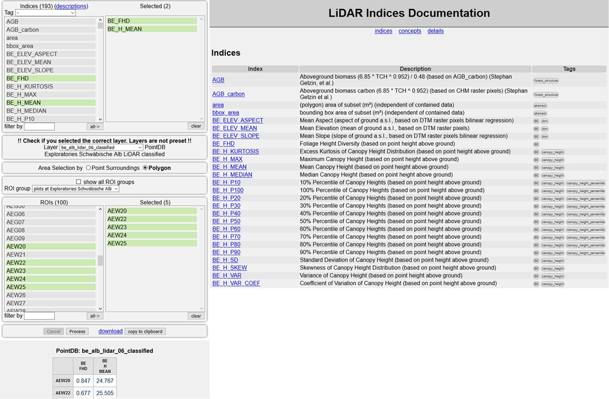

**Figure 8**

Open in figure viewer[PowerPoint](https://onlinelibrary.wiley.com/action/downloadFigures?id=ecog12676-fig-0008&doi=10.1111%2Fecog.05266)

Point cloud indices processing view of the RSDB web interface. On the left: indices and areas can be selected and applied for processing. On the right: index descriptions can be browsed.

## Conclusions

The RSDB enables easy access to web‐based product generation of remote sensing data for a variety of ecological studies. In particular, our web interface enables access to remote sensing data and basic processing without advanced computer science skills. For setup, basic software installation skills are required, but usage is possible exclusively via a web browser. Moreover, the RSDB allows users to execute case‐specific product processing and advanced individual workflows in R through use of our accompanying R package as an interface.

Performance is an important issue for the interactivity and fast processing of large remote sensing datasets. The RSDB was designed to have low storage requirements and efficient multicore processing pipelines. Where reasonable, we implemented streaming architecture for on‐the‐fly data processing and product generation. This is advantageous when a user requests to download a multi‐terabyte‐sized layer, allowing the product to be generated as the download proceeds.

The RSDB was mainly built for single server (or personal computer) setups that are readily available for the majority of researchers who have no computer science background. Extremely large data processing tasks, however, would profit from distributing the computing across multiple machines to obtain faster results. With the RSDB, this is possible by manually spreading tasks over multiple servers. A further direction for the development of the RSDB is to automate the utilization of multiple servers in a high‐performance computing environment.

Our solution is especially powerful in a setting where dataset providers manage data in the RSDB and researches are in the role of data consumers, which is often the case in larger research projects. In particular, if projects run for a longer period, challenges arise as the data amount continually increase and data types further diversify from different devices (e.g. satellites, airplanes, or UAS with continuously developing sensors). In such settings, simple file storage strategies and correct but computationally time consuming software scripts tend to become insufficient even for initially small remote sensing data applications. Central remote sensing data management and analysis solutions such as RSDB are thus necessary to manage data lifecycles (Geiger et al. 2018) while providing transparent documentation for reproducing workflows.

During all stages of a remote sensing workflow, several types of errors may occur (Gahegan and Ehlers 2000). A visual inspection may reveal errors such as incorrect projection, poor image quality or unusual patterns in the resulting products. RSDB offers manifold options to investigate such errors by checking the source data visually using interactive maps with overlays, interactive 3‐D visualizations and identifying exceptional values generated from on‐the‐fly processed indices.

The point cloud indices currently have fixed parameters that cannot be changed by the user. A further area of development for the RSDB will be to enable users to manually set parameters for particular indices. This parametrization will lead to more complexity for users because currently users just need to select desired indices and index variants are covered by naming that variants (which have been utilized in synthesis studies (Bae et al. 2019, Meyer et al. 2019)). However, for some indices, for example AGB, parameterization is indispensable for adapting to different climate zones.

A voxel‐based layer type is in development, which will be a uniform representation of point clouds. Especially for dense point clouds, voxels are an alternative that have low storage demands and fast processing.

Another area of the RSDB's further development is the extension of vector data utilization. Landscape characterization may be available as vector data that originate from combinations of remote sensing datasets and manual acquisitions. Indices from vector data may then contribute to ecosystem modeling, especially by describing the landscape surrounding the study plot.

The RSDB is continuously being developed at the Lab of Environmental Informatics at the Phillips‐Univ. of Marburg. Further development is driven by the requirements of associated projects and open‐source contributors. Current projects managing their own instance of RSDB as a remote sensing data repository are the DFG priority program 1374 – exploratories for large‐scale and long‐term functional biodiversity research (biodiversity‐exploratories.de), the DFG Research Unit 2358 – The Mountain Exile Hypothesis (uni‐marburg.de/en/fb19/dfg2358), and the LOEWE priority program Nature 4.0 – Sensing Biodiversity (uni‐marburg.de/de/fb19/natur40). Dataset access rights are managed by role‐based access control in combination with annotated project‐specific data usage policies. Project managers may also decide to open (some) datasets for public access.

In summary, we developed the RSDB as an open‐source software that can be used to derive a large number of point cloud indices, which can be attributed to its 3‐D nature. The indices are especially suitable for vertically structured environments, such as forests. With a publicly available detailed documentation of these indices, we wish to contribute to their standardization and to promote the wider usage of remote sensing data in ecogeographical studies.

### Data availability statement

A ready‐to‐use RSDB distribution with datasets for exemplary cases can be found at <[github.com/environmentalinformatics‐marburg/rsdb‐data](http://github.com/environmentalinformatics-marburg/rsdb-data)>.

### Software availability

The RSDB is distributed as open‐source software under a GNU Public License (GPLv3) (Free Software Foundation 2007).

Release packages (RSDB 1 and R package), guides, documentation and the source code (in Java for the RSDB, in JavaScript for the web frontend and in R for the R package) are hosted on GitHub (<[github.com/environmentalinformatics‐marburg/rsdb](http://github.com/environmentalinformatics-marburg/rsdb)>).

The RSDB server requires a Java 8 (or newer) environment to run. Scripts for the administration of the RSDB are included for Ubuntu and Windows. Ubuntu is recommended for network usage.

The R package connects to the RSDB server, which may run locally on the same computer or on a remote server). For R package installation, only dependencies inside the R environment are required, which are installed automatically using:

if(!require("remotes")) install.packages("remotes")

remotes::install_github ("environmentalinformatics‐marburg/rsdb/r‐package")

library(RSDB)

To cite the RSDB, cite this Software note with the used RSDB version.

*Acknowledgements* – We thank the scientists of the DFG Biodiversity Exploratories, the DFG Kilimanjaro research unit and the Nature 4.0 consortium for their demands and critical feedback to the software. We also thank the managers of the three Exploratories, Kirsten Reichel‐Jung, Iris Steitz and Sandra Weithmann (Swabian Alb), Katrin Lorenzen and Juliane Vogt (Hainich) and Miriam Teuscher (Schorfheide), all former managers for their work in maintaining the plot and project infrastructure; Christiane Fischer, Anja Hoeck and Cornelia Weist for giving support through the central office, Andreas Ostrowski for managing the central data base, and Markus Fischer, Eduard Linsenmair, Dominik Hessenmöller, Daniel Prati, Ingo Schöning, François Buscot, Ernst‐Detlef Schulze, Wolfgang W. Weisser and the late Elisabeth Kalko for their role in setting up the Biodiversity Exploratories project. Open access funding enabled and organized by Projekt DEAL.

*Funding* – The work has been funded by the DFG Priority Program 1374 ‘Infrastructure‐Biodiversity‐Exploratories' (NA 783/6‐2).

### Author contributions

**Stephan Wöllauer**: Software (lead); Writing – original draft (lead); Writing – review and editing (lead). **Dirk Zeuss**: Writing – original draft (equal); Writing – review and editing (equal). **Paul Magdon**: Writing – original draft (equal); Writing – review and editing (equal). **Thomas Nauss**: Writing – original draft (equal); Writing – review and editing (equal).

[figure not shown]

### Details

- © 2020 The Authors. Ecography published by John Wiley & Sons Ltd on behalf of Nordic Society Oikos

### Keywords

  - [biodiversity indices](https://onlinelibrary.wiley.com/action/doSearch?field1=Keyword&text1=biodiversity%20indices)
  - [data management](https://onlinelibrary.wiley.com/action/doSearch?field1=Keyword&text1=data%20management)
  - hyperspectral
  - LiDAR
  - [spectral indices](https://onlinelibrary.wiley.com/action/doSearch?field1=Keyword&text1=spectral%20indices)
  - [structural indices](https://onlinelibrary.wiley.com/action/doSearch?field1=Keyword&text1=structural%20indices)

### Publication History

  - Version of Record online: 30 November 2020
  - Manuscript accepted: 06 November 2020